# PE zadanie 1

Alicja Hołowiecka

26-03-2020

## Zadanie 1

Wczytaj bibliotekę `survey` (powinna być już zainstalowana), następnie komendą `data(api)` wywołaj listę zbiorów dotyczących szkół w Kaliforni. Będzie to kilka zbiorów, a Ciebie będą interesować głównie dwa: `apisrs` oraz `apipop`. Pierwszy jest próbką 200 elementową populacji `apipop`. Na podsatwie próby oszacuj metodą przedziałową nieznany parametr wartości oczekiwanej zmiennej `enroll` na poziomie ufności 0.99. Sprawdź, czy nieznany parametry (dla Ciebie znany, bo może być wyznaczony na podstawie populacji) należy do przedziału ufności. Narysuj wykres rozkładu zmiennej `enroll` w próbie oraz oceń podstawowe statystki opisowe.

## Zadanie 2

Z wczytanego wcześniej zbioru `apipop` wylosuj 100 próbek o liczebności 36 elementów każda. Następnie napisz funkcję, która będzie liczyła przedział ufności dla frakcji. Zastosuj tą funkcję do zmiennej `sch.wide` mówiącej o tym czy szkoła wypełniła założone przez państwo wymagania dotyczące rozwoju uczniów (kod “Yes”). Sprawdź ile spośród wyznaczonych w ten sposób przedziałów ufności zwierało prawdziwą proporcję szkół spełniających wymagania w populacji. Opisz obszernie wyniki.

# Rozwiązanie

## Zadanie 1

Wczytanie danych:

```r
library(survey)
data(api)
head(apisrs) # próbka
```

```
##                 cds stype            name                         sname snum
## 1039 15739081534155     H  McFarland High                McFarland High 1039
## 1124 19642126066716     E Stowers (Cecil  Stowers (Cecil B.) Elementary 1124
## 2868 30664493030640     H Brea-Olinda Hig              Brea-Olinda High 2868
## 1273 19644516012744     E Alameda Element            Alameda Elementary 1273
## 4926 40688096043293     E Sunnyside Eleme          Sunnyside Elementary 4926
## 2463 19734456014278     E Los Molinos Ele        Los Molinos Elementary 2463
##                         dname dnum           cname cnum flag pcttest api00
## 1039        McFarland Unified  432            Kern   14   NA      98   462
## 1124              ABC Unified    1     Los Angeles   18   NA     100   878
## 2868      Brea-Olinda Unified   79          Orange   29   NA      98   734
## 1273           Downey Unified  187     Los Angeles   18   NA      99   772
## 4926 San Luis Coastal Unified  640 San Luis Obispo   39   NA      99   739
## 2463  Hacienda la Puente Unif  284     Los Angeles   18   NA      93   835
##      api99 target growth sch.wide comp.imp both awards meals ell yr.rnd
```

[output cut: 20 more lines]

```r
head(apipop) # populacja
```

```
##              cds stype            name                      sname snum
## 1 01611190130229     H    Alameda High               Alameda High    1
## 2 01611190132878     H    Encinal High               Encinal High    2
## 3 01611196000004     M  Chipman Middle             Chipman Middle    3
## 4 01611196090005     E Lum (Donald D.) Lum (Donald D.) Elementary    4
## 5 01611196090013     E Edison Elementa          Edison Elementary    5
## 6 01611196090021     E Otis (Frank) El    Otis (Frank) Elementary    6
##                  dname dnum   cname cnum flag pcttest api00 api99 target growth
## 1 Alameda City Unified    6 Alameda    1   NA      96   731   693      5     38
## 2 Alameda City Unified    6 Alameda    1   NA      99   622   589     11     33
## 3 Alameda City Unified    6 Alameda    1   NA      99   622   572     11     50
## 4 Alameda City Unified    6 Alameda    1   NA      99   774   732      3     42
## 5 Alameda City Unified    6 Alameda    1   NA      99   811   784      1     27
## 6 Alameda City Unified    6 Alameda    1   NA     100   780   725      4     55
##   sch.wide comp.imp both awards meals ell yr.rnd mobility acs.k3 acs.46
```

[output cut: 20 more lines]

```r
#help(api)
```

Minimalna liczebność próby:

```r
n_min <- 28 + 25* (e1071::skewness(apipop$enroll, na.rm = T))^2
n_min
```

```
## [1] 160.1118
```

Minimalna liczebność próby wynosi 161. Nasza próba ma 200, więc spełnia ten warunek.

```r
N <- nrow(apipop)
N
```

```
## [1] 6194
```

Liczebność całej populacji wynosi 6194.

Wyznaczanie przedziału ufności:

```r
n <- nrow(apisrs) # 200
alpha <- 0.01
t <- qt(1-alpha/2, n-1)
s <- sd(apisrs$enroll)
m <- mean(apisrs$enroll)
lower <- m-t*s/sqrt(n)
upper <- m+t*s/sqrt(n)
lower
```

```
## [1] 512.2537
```

```r
upper
```

```
## [1] 656.9663
```

Próba ma 200 elementów, nie jest więc mała, możemy korzystać zarówno z kwantyla rozkładu t-Studenta, jak i rozkładu normalnego. Skorzystaliśmy z rozkładu t-Studenta.

Przedział ufności dla średniej na podstawie próby `apisrs`: (512.25; 656.97).

Wyznaczanie przedziału ufności z uwzględnieniem poprawki na populację skończoną:

```r
lower1 <- m-t*sqrt(1-n/N)*s/sqrt(n)
upper1 <- m+t*sqrt(1-n/N)*s/sqrt(n)
lower1
```

```
## [1] 513.4314
```

```r
upper1
```

```
## [1] 655.7886
```

Przedział ufności dla średniej z uwzględnieniem poprawki na populację skończoną ma postać (513.43; 655.79). Różnica jest nieznaczna w stosunku do przedziału ufności wyznaczonego bez poprawki.

Wartość oczekiwana z całej populacji:

```r
m_pop <- mean(apipop$enroll, na.rm = 1)
m_pop
```

```
## [1] 619.0469
```

Średnia z całej populacji (czyli nasz “nieznany” parametr) wynosi 619.05, zatem mieści się w przedziale ufności wyznaczonym na podstawie próbki (zarówno z poprawką na populację skończoną, jak i bez niej).

Histogram dla zmiennej `enroll` w próbie:

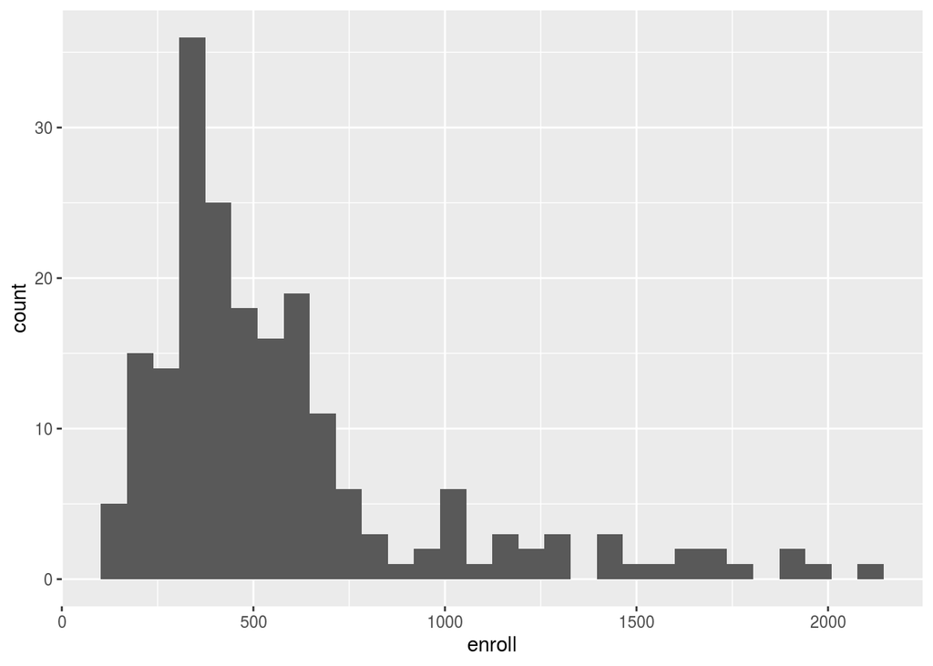

```r
library(tidyverse)
apisrs %>%
  ggplot(aes(x = enroll))+
  geom_histogram()
```

Z wykresu widać, że zmienna `enroll` jest prawostronnie asymetryczna.

Podstawowe statystyki opisowe dla zmniennej `enroll` w próbie: liczebność, minimum, pierwszy kwartyl, średnia, mediana, trzeci kwartyl, maksimum, odchylenie standardowe.

```r
apisrs %>%
  summarise(n= n(),
            min = min(enroll, na.rm = 1),
            Q1 = quantile(enroll, 0.25),
            mean = mean(enroll, na.rm = 1),
            median = median(enroll, na.rm = 1),
            Q3 = quantile(enroll, 0.75),
            max = max(enroll, na.rm = 1),
            sd = sd(enroll, na.rm = 1))
```

```
##     n min  Q1   mean median    Q3  max       sd
## 1 200 131 339 584.61    453 668.5 2106 393.4514
```

## Zadanie 2

```r
head(apipop$sch.wide)
```

```
## [1] Yes Yes Yes Yes Yes Yes
## Levels: No Yes
```

```r
sum(is.na(apipop$sch.wide))
```

```
## [1] 0
```

Zmienna `sch.wide` to zmienna o dwóch poziomach `Yes` i `No`. Nie występują w niej braki danych.

Przekodujemy `Yes` i `No` w zmiennej `sch.wide` na 1 i 0.

```r
apipop$sch.wide <- as.numeric(apipop$sch.wide)-1
```

Losujemy 100 próbek o liczebności 36.

```r
set.seed(2020)
proby <- 1:100 %>%
  map(~sample_n(apipop, 36))
```

Przedział ufności dla frakcji wyznaczamy ze wzoru:

$$p \in (\frac{m}{n} - u_{1−α/2}\frac{\sqrt{\frac{m}{n}(1-\frac{m}{n})}}{\sqrt{n}};
\frac{m}{n} + u_{1−α/2}\frac{\sqrt{\frac{m}{n}(1-\frac{m}{n})}}{\sqrt{n}})$$
gdzie:

n - liczba wszystkich przypadków

m - liczba wyróżnionych przypadków

u - kwantyl rozkładu normalnego

Funkcja licząca przedział ufności dla frakcji wygląda następująco:

```r
ci_frakcja <- function(dane, alpha){
  m <- sum(dane)
  n <- length(dane)
  u <- qnorm(1-alpha/2)
  lower <- m/n-u*sqrt(m/n*(1-m/n))/sqrt(n)
  upper <- m/n+u*sqrt(m/n*(1-m/n))/sqrt(n)
  return(c(lower, upper))
}
```

Funkcja ta zwraca wektor składający się z lewego i prawego końca przedziału ufności.

Wyznaczanie przedziałów ufności dla wylosowanych wcześniej prób:

```r
przedzialy <- proby %>%
  map(~ci_frakcja(.x$sch.wide, 0.05))
```

Proporcja w całej populacji:

```r
prop <- mean(apipop$sch.wide)
prop
```

```
## [1] 0.8269293
```

Proporcja szkół, które spełniają wymagania (`sch.wide = Yes`) do wszystkich szkół wynosi 83%.

Sprawdzimy, ile przedziałów ufności pokrywa ten szukany parametr:

```r
przedzialy %>%
  map_dbl(~{
    ifelse(between(prop, .x[1], .x[2]), 1, 0)

  }) %>%
  sum()
```

```
## [1] 91
```

Dla 91 ze 100 próbek, wyznaczony 95-procentowy przedział ufności pokrywa szukany parametr.